# Where1M1

## Adding coordinates of transmiting and receiving points

Transmitters and receivers coordinates for the simulation are stored in **.ini** files. Transmitter and Receiver are instances of the class `RadioNode` which offers different methods for specifying nodes positions. The stucture of this **.ini** file presented below. The node Id is associated with the 3 coordinates $x,y,z$ separated by white spaces.

```
[coordinates]
1 = -12.2724 7.76319999993 1.2
2 = -18.7747 15.1779999998 1.2
3 = -4.14179999998 8.86029999983 1.2
4 = -9.09139999998 15.1899000001 1.2
```

```python
S.tx = RadioNode(_fileini='w2m1rx.ini',_fileant='defant.vsh3')
S.rx = RadioNode(_fileini='w2m1tx.ini',_fileant='defant.vsh3')
```

The whole simulation setup can then be displayed using the **show** method of the Simulation object

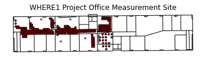

```python
fig,ax = S.show()
```

Select Tx and Rx positions

```python
map={1: 1,2: 2, 3: 3, 4: 5, 5: 6, 6: 7, 7: 8, 8: 9, 9: 10,
10: 11, 11: 12, 12: 13, 13: 14, 14: 15, 15: 16, 16: 17, 17: 18, 18: 19, 19: 20,
20: 21, 21: 22, 22: 23, 23: 24, 24: 25, 25: 26, 26: 27,
27: 28, 28: 29, 29: 30, 30: 32, 31: 33, 32: 34, 33: 35, 34: 36, 35: 37, 36: 38,
      37: 39, 38: 40, 39: 41, 40: 42, 41: 43, 42: 44, 43: 45, 44: 46, 45: 47,
      46: 48, 47: 49, 48: 50, 49: 51, 50: 52, 51: 53, 52: 54, 53: 55, 54: 56,
      55: 57, 56: 58, 57: 59, 58: 60, 59: 61, 60: 62, 61: 63, 62: 64, 63: 65,
      64: 66, 65: 67, 66: 68, 67: 69, 68: 70, 69: 71, 70: 72, 71: 73, 72: 74,
      73: 75, 74: 76, 75: 77, 76: 78, 77: 79, 78: 80, 79: 81, 80: 82, 81: 83,
      82: 84, 83: 85, 84: 89, 85: 90, 86: 91, 87: 92, 88: 93, 89: 94, 90: 95,
      91: 96, 92: 97, 93: 98, 94: 99, 95: 100, 96: 101, 97: 103, 98: 104, 99:
      105, 100: 106, 101: 107, 102: 108, 103: 109, 104: 110, 105: 111, 106:
      113, 107: 114, 108: 116, 109: 117, 110: 119, 111: 120, 112: 122, 113:
      123, 114: 124, 115: 125, 116: 126, 117: 127, 118: 128, 119: 129, 120:
      133, 121: 134, 122: 136, 123: 137, 124: 138, 125: 139, 126: 140, 127:
      141, 128: 142, 129: 143, 130: 144, 131: 145, 132: 146, 133: 147, 134:
      162, 135: 163, 136: 164, 137: 165, 138: 166, 139: 167, 140: 168, 141:
      169, 142: 170, 143: 171, 144: 172, 145: 173, 146: 174, 147: 175, 148:
      176, 149: 177, 150: 179, 151: 180, 152: 181, 153: 182, 154: 183, 155:
      184, 156: 185, 157: 186, 158: 188, 159: 189, 160: 199, 161: 200, 162:
      201, 163: 202, 164: 203, 165: 204, 166: 205, 167: 206, 168: 207, 169:
      208, 170: 209, 171: 210, 172: 211, 173: 212, 174: 213, 175: 214, 176:
      215, 177: 216, 178: 217, 179: 218, 180: 219, 181: 220, 182: 221, 183:
      222, 184: 223, 185: 227, 186: 228, 187: 229, 188: 230, 189: 231, 190:
      232, 191: 233, 192: 234, 193: 235, 194: 236, 195: 237, 196: 238, 197:
      239, 198: 240, 199: 241, 200: 242, 201: 243, 202: 244, 203: 245, 204:
      246, 205: 247, 206: 248, 207: 249, 208: 250, 209: 251, 210: 252, 211:
      253, 212: 258, 213: 259, 214: 266, 215: 267, 216: 268, 217: 269, 218:
      270, 219: 271, 220: 272, 221: 273, 222: 274, 223: 275, 224: 276, 225:
      277, 226: 278, 227: 279, 228: 297, 229: 298, 230: 299, 231: 300, 232:
      301, 233: 302, 234: 303, 235: 304, 236: 305, 237: 306, 238: 307, 239:
      308, 240: 309, 241: 310, 242: 311, 243: 312, 244: 313, 245: 314, 246:
      315, 247: 316, 248: 317, 249: 318, 250: 319, 251: 320, 252: 321, 253:
      322, 254: 323, 255: 324, 256: 325, 257: 326, 258: 327, 259: 328, 260:
      329, 261: 330, 262: 332, 263: 333, 264: 334, 265: 335, 266: 336, 267:
      337, 268: 338, 269: 339, 270: 340, 271: 341, 272: 342, 273: 343, 274:
      344, 275: 345, 276: 346, 277: 347, 278: 348, 279: 349, 280: 350, 281:
      351, 282: 352, 283: 353, 284: 354, 285: 355, 286: 356, 287: 360, 288:
      361, 289: 362, 290: 363, 291: 364, 292: 365, 293: 366, 294: 367, 295:
      368, 296: 369, 297: 370, 298: 371, 299: 372, 300: 373, 301: 374, 302:
      375}
```

```python
print 'number of Tx :',len(S.tx.points.keys())
print 'number of rx :',len(S.rx.points.keys())
```

```
number of Tx : 302
number of rx : 4
```

Choose measurement points

```python
# Chose used points here

itx=10
irx=2


# check points
tx= S.tx.points[itx]
rx= S.rx.points[irx]
M = UWBMeasure(map[itx])
txm = M.tx
rxm = M.rx[irx]
print tx,txm
print rx,rxm

if (tx[0] - txm[0] > 0.001) or (tx[1] - txm[1] > 0.001):
    print 'Tx and Txm are not the same !'
else :
    print 'Txs OK'
if (rx[0] - rxm[0] > 0.001) or (rx[1] - rxm[1] > 0.001):
    print 'Rx and Rxm are not the same !'
else :
    print 'Rxs OK'
```

```
[-24.867   12.3097   1.2   ] [-24.867   12.3097   1.2   ]
[-18.7747  15.178    1.2   ] [-18.7747  15.178    1.2   ]
Txs OK
Rxs OK
```

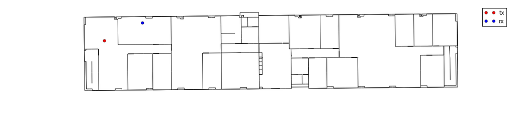

```python
fig =plt.figure(figsize=(20,20))
fig,ax=S.L.showG('s',fig=fig)
ax.plot(M.tx[0],M.tx[1],'or',label='tx')
ax.plot(M.rx[irx][0],M.rx[irx][1],'ob',label='rx')
ax.legend()
```

## Signatures, Rays and channel

A signature is a sequence of layout objects (points and segments) which are involved in a given optical ray joinint the transmiter and the receiver. The signatutre is calculated from a layout cycle to an other layout cycle. This means that is is required first to retrieve the cycle number from point coordinates. This is done thanks to the **pt2cy**, point to cycle function.

```python
ctx=S.L.pt2cy(tx)
crx=S.L.pt2cy(rx)
print 'tx point belongs to cycle ',ctx
print 'rx point belongs to cycle ',crx
```

```
tx point belongs to cycle  6
rx point belongs to cycle  3
```

```python
Si = Signatures(S.L,ctx,crx)
Si.run5(cutoff=3)
```

```python
tx[2]=1.5
```

```python
r2d = Si.rays(tx,rx)
r3d=r2d.to3D(S.L)
```

[output not shown]

[output cut: 37 more lines]

[output not shown]

```python
r2d.show(S.L,figsize=(20,10),nodes=False)
```

[output not shown]

```python
r2d.show(S.L,figsize=(20,10))
```

[output not shown]

```python
r3d.locbas(S.L)
r3d.fillinter(S.L)
r3d
```

```python
r3d
```

```python
S.freq()
```

```python
Ct = r3d.eval(S.freq())
```

The `energy` method calculates the energy hoeld by each ray

```python
Ct.energy()
```

## Apply waveform

```python
Ct.freq = S.freq
sco= Ct.prop2tran(a='theta',b='theta')
sca= Ct.prop2tran(a=S.tx.A,b=S.rx.A)
```

```python
wav = wvf.Waveform(typ='W1offset')
#wav = wvf.Waveform({'type' : 'generic','band': 0.499,'fc': 4.493, 'fe': 100, 'thresh': 3, 'tw': 30})
wav.show()
```

```python
sco.isFriis
```

```python
if sco.isFriis:
    ciro = sco.applywavB(wav.sf)
else:
    ciro = sco.applywavB(wav.sfg)
if sca.isFriis:
    cira = sca.applywavB(wav.sf)
else:
     cira = sca.applywavB(wav.sfg)
```

```python
ciro.plot(typ='v')
title(u'received waveform without antenna $\\theta\\theta$')
```

```python
cira.plot(typ='v')
title('received waveform with antenna')
```

```python
#dchan={i:'ch'+str(i) for i in range(1,5)}
dchan={}
dchan[1]='ch3'
dchan[2]='ch4'
dchan[3]='ch1'
dchan[4]='ch2'
```

```python
fig = plt.figure()
ax1 = fig.add_subplot(311,title="Measurements")
cmd='M.tdd.' + str(dchan[irx]) + '.plot(ax=ax1)'
eval(cmd)
title('WHERE1 measurement')
#M.tdd.ch2.plot()
# align for plotting
#ciro.x=ciro.x-ciro.x[0]
ax2 = fig.add_subplot(312,title="Simulation-with antenna",sharex=ax1, sharey=ax1)
plt.xlim(20,70)
plt.ylim(-95,-50)
u = cira.plot(ax=ax2)
title('Simulation-with antenna - without noise')
plt.tight_layout()
#ax3 = fig.add_subplot(313,title="Simulation-without antenna",sharex=ax1, sharey=ax1)
#ciro.plot()
```

[output not shown]

```python
v = tx-rx
d = sqrt(dot(v,v))

print 'real delay between tx and rx',d/0.3
print 'simulated first path delay',r3d.delays[0]
```

[output not shown]

```python
r3d.delays
```

```python
r3d.info(0)
```

```python
Ct.doadod(phi=(-180,180))
```